# cv9.R

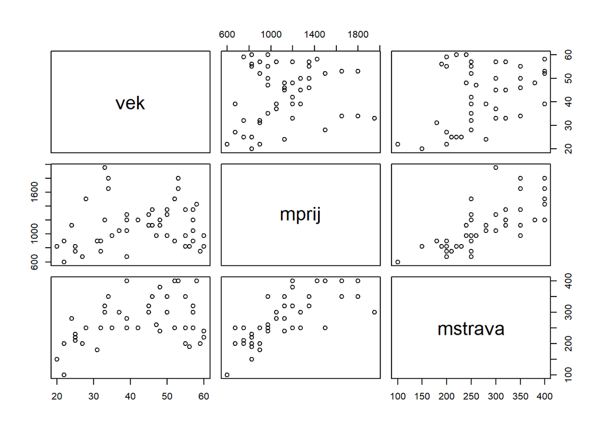

```r
pairs(data[,c('vek', 'mprij', 'mstrava')])
```

```r
korelacie(data$mprij, data$mstrava)
```

```
##   Pearson   Kendall  Spearman
## 0.7276575 0.6340417 0.7882542
```

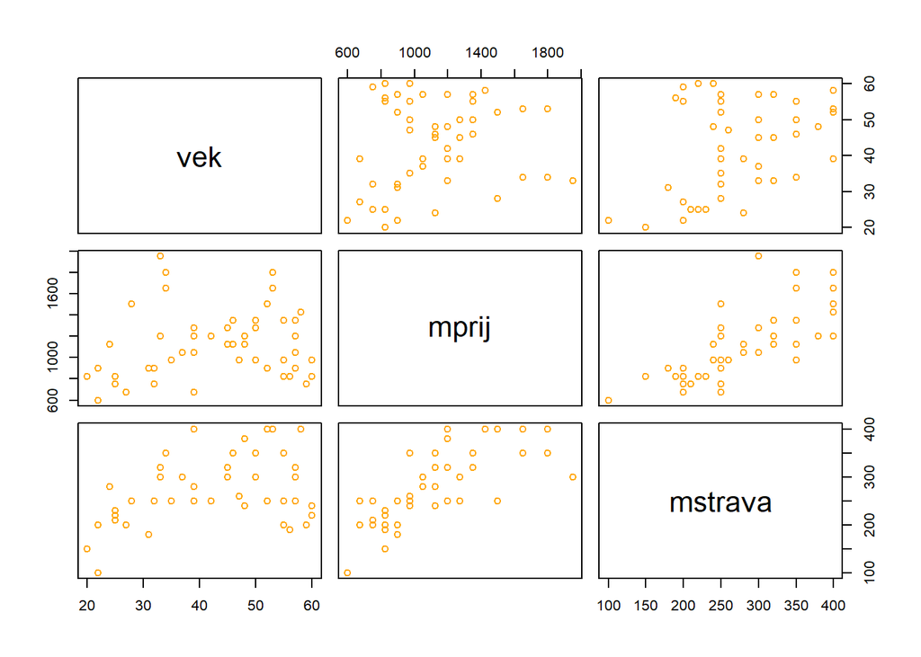

```r
pairs(data[,c('vek', 'mprij', 'mstrava')], col='orange')
```

```r
library(GGally)
```

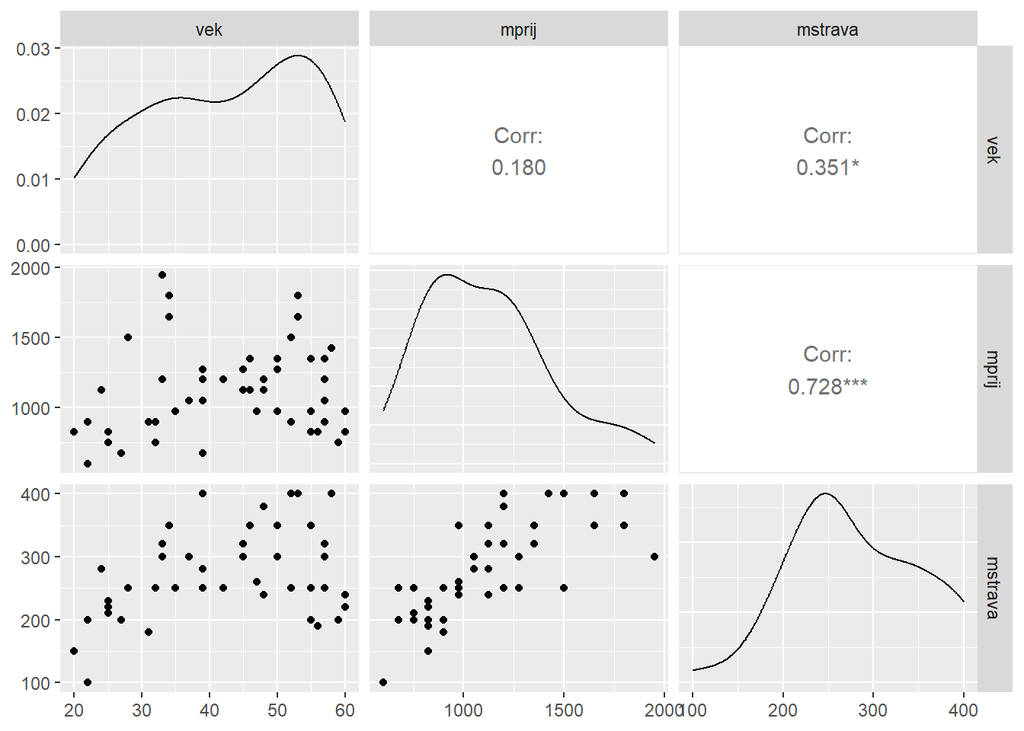

```r
ggpairs(data[,c('vek', 'mprij', 'mstrava')])
```

toto boli graficke analyzy pre cely datovy subor Mozeme analyzovat aj podmnoziny datoveho suboru

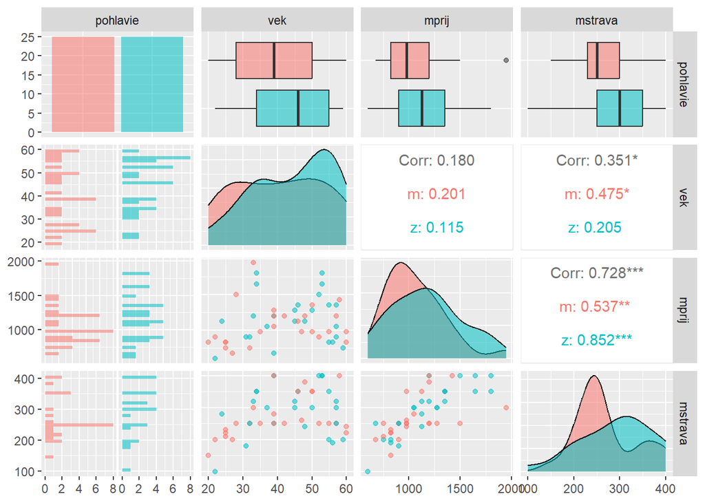

```r
ggpairs(data[,c('pohlavie', 'vek', 'mprij', 'mstrava')],
        aes(colour=pohlavie, alpha = 0.3))
```

# Regresna analyza

Ked korelacne koeficienty su vysoke, teda data su linearne zavisle, tak nasleduje regresna analyza. Snazime sa zavislost popisat vhodnou funkciou - regresna funkcia, priklad zo zaciatku, prelozime priamku y=a+bx

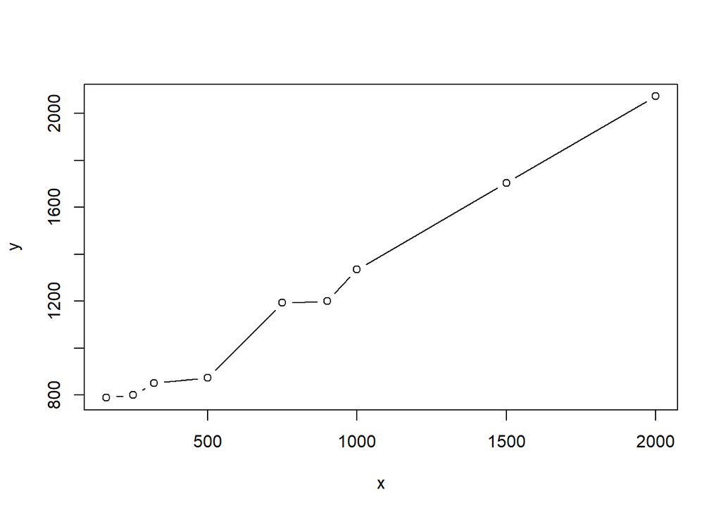

```r
plot(x, y, type = 'b')
```

```r
lr1 <- lm(y~x)
lr1
```

```
##
## Call:
## lm(formula = y ~ x)
##
## Coefficients:
## (Intercept)            x
##    609.6629       0.7225
```

```r
summary(lr1)
```

```
##
## Call:
## lm(formula = y ~ x)
##
## Residuals:
##     Min      1Q  Median      3Q     Max
## -96.912   2.839  10.138  18.341  63.737
##
## Coefficients:
##              Estimate Std. Error t value Pr(>|t|)
## (Intercept) 609.66288   30.45571   20.02 1.94e-07 ***
## x             0.72250    0.03035   23.81 5.87e-08 ***
## ---
## Signif. codes:  0 '***' 0.001 '**' 0.01 '*' 0.05 '.' 0.1 ' ' 1
##
## Residual standard error: 52.67 on 7 degrees of freedom
## Multiple R-squared:  0.9878, Adjusted R-squared:  0.9861
## F-statistic: 566.7 on 1 and 7 DF,  p-value: 5.867e-08
```

Multiple R-squared -> cim blizsie k 1, tym lepsi model -> 98% dat je vysvetlenych nasou priamkou

```r
#abline(lr1, col = 'red')
```

Ak konstantu neuvazujeme

```r
lr2 <- lm(y~0+x)
summary(lr2)
```

```
##
## Call:
## lm(formula = y ~ 0 + x)
##
## Residuals:
##    Min     1Q Median     3Q    Max
## -364.9  103.0  264.5  460.9  594.0
##
## Coefficients:
##   Estimate Std. Error t value Pr(>|t|)
## x   1.2189     0.1249    9.76 1.02e-05 ***
## ---
## Signif. codes:  0 '***' 0.001 '**' 0.01 '*' 0.05 '.' 0.1 ' ' 1
##
## Residual standard error: 376 on 8 degrees of freedom
## Multiple R-squared:  0.9225, Adjusted R-squared:  0.9128
## F-statistic: 95.26 on 1 and 8 DF,  p-value: 1.017e-05
```

```r
#abline(lr2, col = 'green')
```

prelozime kvadraticku funckiu

```r
lr3 <- lm(y~poly(x, 2))
summary(lr3)
```

```
##
## Call:
## lm(formula = y ~ poly(x, 2))
##
## Residuals:
##     Min      1Q  Median      3Q     Max
## -91.634 -12.870   2.168  25.098  58.875
##
## Coefficients:
##             Estimate Std. Error t value Pr(>|t|)
## (Intercept)  1202.11      17.36  69.241 6.11e-10 ***
## poly(x, 2)1  1253.78      52.08  24.072 3.38e-07 ***
## poly(x, 2)2    56.04      52.08   1.076    0.323
## ---
## Signif. codes:  0 '***' 0.001 '**' 0.01 '*' 0.05 '.' 0.1 ' ' 1
##
## Residual standard error: 52.08 on 6 degrees of freedom
## Multiple R-squared:  0.9898, Adjusted R-squared:  0.9864
## F-statistic: 290.3 on 2 and 6 DF,  p-value: 1.07e-06
```

```r
#lines(x, fitted(lr3), col = 'blue')
```